# Fuzzy Alpha-cut Ridge Estimation: Total Multicollinearity Data

2018/ 11/ 11

We give an example to illustrate the mechanism of our fuzzy alpha-cut linear regression. The data presented below were taken from Hong et al..

## Example 2 - Total Multicollinearity data

```r
# Y is a fuzzy dataset.
y <- c(12.5, 17.0, 18.5, 22.0, 24.0, 26.5, 28.0,
       31.5, 33.5, 37.0, 38.5, 41.5, 43.5, 46.5, 49.0) # center of Dependent variable Y.
s <- c(rep(5, 10), rep(6, 5)) # spread of Dependent variable Y
f_Y <- cbind(y-s, y, y+s)

# Covariates x1, x2 are crisp.
x1 <- c(2.3, 3.2, 3.5, 4.2, 4.6, 5.1, 5.4,
        6.1, 6.5, 7.2, 7.5, 8.1, 8.5, 9.1, 9.6)
x2 <- 2 * x1 -1
X <- cbind(x1, x2)
sX <- scale(X, center = TRUE, scale = TRUE)
```

One of the assumptions of linear regression is that there is no multicollinearity between the explanatory variables. Multicollinearity can be detected in the following ways.

```r
cor(X)
```

```
##    x1 x2
## x1  1  1
## x2  1  1
```

```r
vif(as.data.frame(X))
```

```
##   Variables VIF
## 1        x1 Inf
## 2        x2 Inf
```

## STEP 1.

Create an $\alpha$ - level of the dependent variable Y. The set of $\alpha$ - levels is given by $A = \{1, 0.75, 0.5, 0.25, 0\}$.

```r
A <- c(1, 0.75, 0.5, 0.25, 0)
len.A <- length(A)

n <- length(y)
p <- ncol(X)

l_Y <- matrix(NA, nrow = n, ncol = len.A)
r_Y <- matrix(NA, nrow = n, ncol = len.A)

for (a in 1:len.A) {
  x_L <- s*A[a] + y - s
  x_R <- -s*A[a] + y + s

  l_Y[, a] <- x_L
  r_Y[, a] <- x_R
}

colnames(l_Y) <- c("l_Y(1)", "l_Y(0.75)", "l_Y(0.5)", "l_Y(0.25)", "l_Y(0)")
colnames(r_Y) <- c("r_Y(1)", "r_Y(0.75)", "r_Y(0.5)", "r_Y(0.25)", "r_Y(0)")
```

```r
l_Y
```

```
##       l_Y(1) l_Y(0.75) l_Y(0.5) l_Y(0.25) l_Y(0)
##  [1,]   12.5     11.25     10.0      8.75    7.5
##  [2,]   17.0     15.75     14.5     13.25   12.0
##  [3,]   18.5     17.25     16.0     14.75   13.5
##  [4,]   22.0     20.75     19.5     18.25   17.0
##  [5,]   24.0     22.75     21.5     20.25   19.0
##  [6,]   26.5     25.25     24.0     22.75   21.5
##  [7,]   28.0     26.75     25.5     24.25   23.0
##  [8,]   31.5     30.25     29.0     27.75   26.5
##  [9,]   33.5     32.25     31.0     29.75   28.5
## [10,]   37.0     35.75     34.5     33.25   32.0
## [11,]   38.5     37.00     35.5     34.00   32.5
## [12,]   41.5     40.00     38.5     37.00   35.5
## [13,]   43.5     42.00     40.5     39.00   37.5
## [14,]   46.5     45.00     43.5     42.00   40.5
## [15,]   49.0     47.50     46.0     44.50   43.0
```

```r
r_Y
```

```
##       r_Y(1) r_Y(0.75) r_Y(0.5) r_Y(0.25) r_Y(0)
##  [1,]   12.5     13.75     15.0     16.25   17.5
##  [2,]   17.0     18.25     19.5     20.75   22.0
##  [3,]   18.5     19.75     21.0     22.25   23.5
##  [4,]   22.0     23.25     24.5     25.75   27.0
##  [5,]   24.0     25.25     26.5     27.75   29.0
##  [6,]   26.5     27.75     29.0     30.25   31.5
##  [7,]   28.0     29.25     30.5     31.75   33.0
##  [8,]   31.5     32.75     34.0     35.25   36.5
##  [9,]   33.5     34.75     36.0     37.25   38.5
## [10,]   37.0     38.25     39.5     40.75   42.0
## [11,]   38.5     40.00     41.5     43.00   44.5
## [12,]   41.5     43.00     44.5     46.00   47.5
## [13,]   43.5     45.00     46.5     48.00   49.5
## [14,]   46.5     48.00     49.5     51.00   52.5
## [15,]   49.0     50.50     52.0     53.50   55.0
```

## STEP 2. - STEP 5.

Note that for each $\alpha$ - level the ridge fuzzy coefficients decrease to 0 as lambda increase. This is illustrated in the plot below, which shows the profile plot of ridge coefficients for all $\alpha$ - levels.

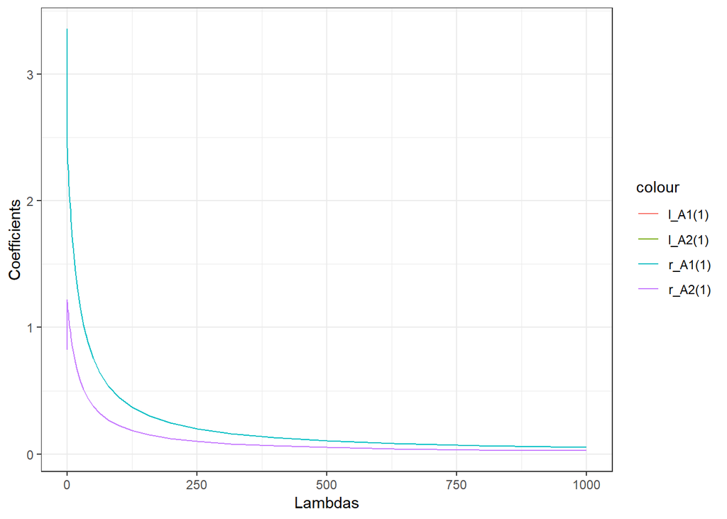

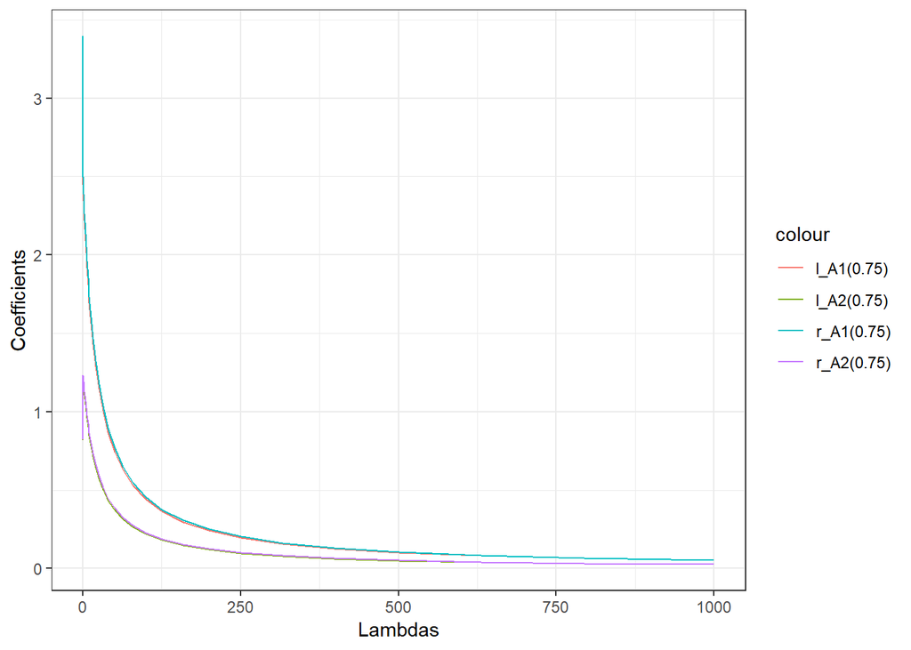

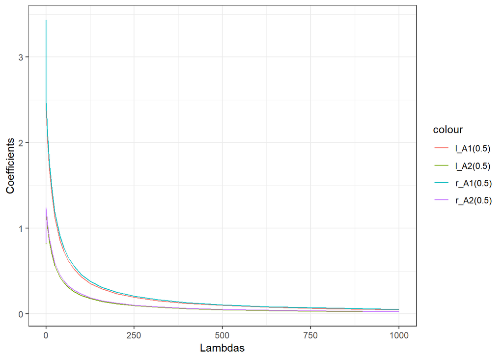

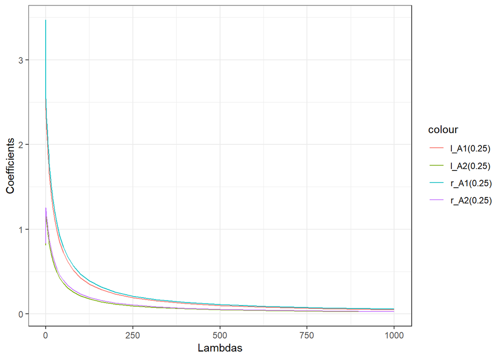

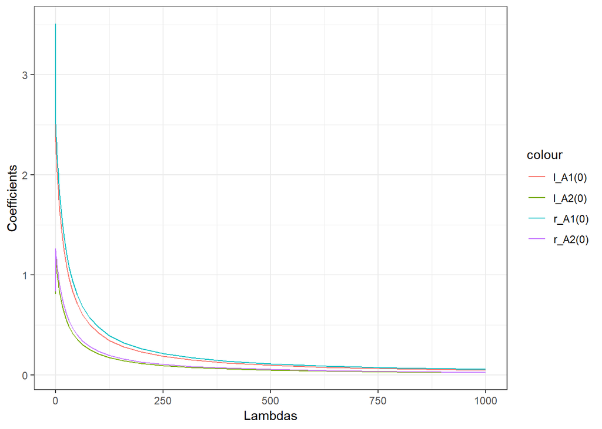

Now obtain the ridge fuzzy regression coefficients based on the optimal lambda value.

```r
l_opt_lambda <- matrix(NA, nrow = len.A, ncol = 1)
r_opt_lambda <- matrix(NA, nrow = len.A, ncol = 1)

l_Ak <- matrix(NA, nrow = p + 1, ncol = len.A)
r_Ak <- matrix(NA, nrow = p + 1, ncol = len.A)

l_Ak_var <- matrix(NA, nrow = p, ncol = len.A)
r_Ak_var <- matrix(NA, nrow = p, ncol = len.A)

for (a in 1:len.A) {
  # optimal lambda values
  l_opt_lambda[a] <- cv.glmnet(X, l_Y[, a], alpha = 0)$lambda.min
  r_opt_lambda[a] <- cv.glmnet(X, r_Y[, a], alpha = 0)$lambda.min

  # estimated ridge fuzzy regression coefficients
  l_fit <- glmnet(X, l_Y[, a], alpha = 0, lambda = l_opt_lambda[a])
  r_fit <- glmnet(X, r_Y[, a], alpha = 0, lambda = r_opt_lambda[a])

  l_Ak[, a] <- as.matrix(coef(l_fit))
  r_Ak[, a] <- as.matrix(coef(r_fit))

  # std. errors for the estimated ridge fuzzy regression coefficients
  l_yhat   <- predict(l_fit, newx = X, s='lambda.min')
  r_yhat   <- predict(r_fit, newx = X, s='lambda.min')

  #l_Ak_var[, a]   <- ridge_se(sX , y, l_yhat, l_fit)
  #r_Ak_var[, a]   <- ridge_se(sX , y, r_yhat, r_fit)
}

rownames(l_opt_lambda) <- c("alpha = 1", "alpha = 0.75", "alpha = 0.5", "alpha = 0.25", "alpha = 0")
colnames(l_opt_lambda) <- c("opt.lambda")

rownames(r_opt_lambda) <- c("alpha = 1", "alpha = 0.75", "alpha = 0.5", "alpha = 0.25", "alpha = 0")
colnames(r_opt_lambda) <- c("opt.lambda")

colnames(l_Ak) <- c("alpha = 1", "alpha = 0.75", "alpha = 0.5", "alpha = 0.25", "alpha = 0")
rownames(l_Ak) <- c("Intercept", "l_A1", "l_A2")

colnames(r_Ak) <- c("alpha = 1", "alpha = 0.75", "alpha = 0.5", "alpha = 0.25", "alpha = 0")
rownames(r_Ak) <- c("Intercept", "r_A1", "r_A2")

#colnames(l_Ak_var) <- c("alpha = 1", "alpha = 0.75", "alpha = 0.5", "alpha = 0.25", "alpha = 0")
#rownames(l_Ak_var) <- c("l_A1", "l_A2")

#colnames(r_Ak_var) <- c("alpha = 1", "alpha = 0.75", "alpha = 0.5", "alpha = 0.25", "alpha = 0")
#rownames(r_Ak_var) <- c("r_A1", "r_A2")
```

```r
l_Ak
```

```
##           alpha = 1 alpha = 0.75 alpha = 0.5 alpha = 0.25  alpha = 0
## Intercept  3.627426     2.536719    1.445956    0.3551368 -0.7357412
## l_A1       2.386827     2.365901    2.344981    2.3240663  2.3031585
## l_A2       1.187806     1.177391    1.166978    1.1565667  1.1461571
```

```r
r_Ak
```

```
##           alpha = 1 alpha = 0.75 alpha = 0.5 alpha = 0.25 alpha = 0
## Intercept  3.627426     4.718079    5.808680     6.899230  7.989729
## r_A1       2.386827     2.407760    2.428698     2.449642  2.470591
## r_A2       1.187806     1.198222    1.208640     1.219060  1.229481
```

A Summary of the obtained above results in tabular is given below.

Summary of l_Ak

|  | opt.lambda | l_A1 Estimate | l_A1 Std.Error | l_A2 Estimate | l_A2 Std.Error |
| --- | --- | --- | --- | --- | --- |
| alpha = 1 | 1.089924 | 2.386827 | NA | 1.187806 | NA |
| alpha = 0.75 | 1.080366 | 2.365901 | NA | 1.177391 | NA |
| alpha = 0.5 | 1.070809 | 2.344981 | NA | 1.166978 | NA |
| alpha = 0.25 | 1.061252 | 2.324066 | NA | 1.156567 | NA |
| alpha = 0 | 1.051695 | 2.303158 | NA | 1.146157 | NA |

Summary of r_Ak

|  | opt.lambda | r_A1 Estimate | r_A1 Std.Error | r_A2 Estimate | r_A2 Std.Error |
| --- | --- | --- | --- | --- | --- |
| alpha = 1 | 1.089924 | 2.386827 | NA | 1.187806 | NA |
| alpha = 0.75 | 1.099481 | 2.407760 | NA | 1.198222 | NA |
| alpha = 0.5 | 1.109038 | 2.428698 | NA | 1.208640 | NA |
| alpha = 0.25 | 1.118595 | 2.449642 | NA | 1.219060 | NA |
| alpha = 0 | 1.128152 | 2.470591 | NA | 1.229481 | NA |

Modify the intermediate estimators $\bar{l_{A_{k}}}(\alpha)$, and $\bar{r_{A_{k}}}(\alpha)$ so that the estimated coefficients form a pre-defined shape of the membership function.

For each $A_k$, $k = 1, \cdots, p$, compare the $\alpha$ - levels with that of the previous level, i.e., use the *min* and *max* operators to obtain $\hat{l_{A_{k}}}(\alpha)$, and $\hat{r_{A_{k}}}(\alpha)$ for each $k = 1, \cdots, p$. Note that we do not modify the intercept.

```r
#l_A0 <- c(l_Ak[1,], r_Ak[1,]) # Keep the intercepts for late use.
#temp_l_Ak <- l_Ak[-1, ]
#temp_r_Ak <- r_Ak[-1, ]

temp_l_Ak <- l_Ak
temp_r_Ak <- r_Ak

for (i in 1:(p + 1)) {
  for (j in 2:len.A) {
    temp_l_Ak[i, j] <-  ifelse(temp_l_Ak[i, j] <= temp_l_Ak[i, j-1], temp_l_Ak[i, j], temp_l_Ak[i, j-1])
    temp_r_Ak[i, j] <-  ifelse(temp_r_Ak[i, j] >= temp_r_Ak[i, j-1], temp_r_Ak[i, j], temp_r_Ak[i, j-1])
  }
}

temp_lr_Ak <- data.frame(t(temp_l_Ak), t(temp_r_Ak))
```

```r
temp_lr_Ak
```

```
##               Intercept     l_A1     l_A2 Intercept.1     r_A1     r_A2
## alpha = 1     3.6274262 2.386827 1.187806    3.627426 2.386827 1.187806
## alpha = 0.75  2.5367190 2.365901 1.177391    4.718079 2.407760 1.198222
## alpha = 0.5   1.4459563 2.344981 1.166978    5.808680 2.428698 1.208640
## alpha = 0.25  0.3551368 2.324066 1.156567    6.899230 2.449642 1.219060
## alpha = 0    -0.7357412 2.303159 1.146157    7.989729 2.470591 1.229481
```

## STEP 6.

Find the membership function $\mu_{A_{k}}(x)$ for the fuzzy regression coefficients $A_{k}$, $k = 1, \cdots, p$ by performing linear regression on the estimated $\alpha$ -level sets $\hat{A_{k}}(\alpha_j) = [\hat{l_{A_{k}}}(\alpha_j), \hat{r_{A_{k}}}(\alpha_j)]$, for all $\alpha \in A$. Give constraints so that the top of the pre-defined membership function satisfy the condition of $\alpha$ - level 1.

### 1.

Find each of the left and right slopes for the pre-defined membership function.

```r
(lr_Ak <- data.frame(y = A,
                    temp_lr_Ak))
```

```
##                 y  Intercept     l_A1     l_A2 Intercept.1     r_A1
## alpha = 1    1.00  3.6274262 2.386827 1.187806    3.627426 2.386827
## alpha = 0.75 0.75  2.5367190 2.365901 1.177391    4.718079 2.407760
## alpha = 0.5  0.50  1.4459563 2.344981 1.166978    5.808680 2.428698
## alpha = 0.25 0.25  0.3551368 2.324066 1.156567    6.899230 2.449642
## alpha = 0    0.00 -0.7357412 2.303159 1.146157    7.989729 2.470591
##                  r_A2
## alpha = 1    1.187806
## alpha = 0.75 1.198222
## alpha = 0.5  1.208640
## alpha = 0.25 1.219060
## alpha = 0    1.229481
```

```r
slopes <- matrix(NA, nrow = (p + 1), ncol = 3)

for (i in 1:(p + 1)) {
  # left slope
  slopes[i, 1] <- lm(I(lr_Ak[, 1] - lr_Ak[1, 1]) ~ I(lr_Ak[, (i + 1)] - lr_Ak[1, (i + 1)]) + 0)$coef
  # center value
  slopes[i, 2] <- lr_Ak[1, (i + 1)]  #### changed!!
  # right slope
  slopes[i, 3] <- lm(I(lr_Ak[, 1] - lr_Ak[1, 1]) ~ I(lr_Ak[, (i + p + 2)] - lr_Ak[1, (i + p + 2)]) + 0)$coef
}

rownames(slopes) <- c("Intercept", "A1", "A2")
colnames(slopes) <- c("left.slope", "Ak(1)","right.slope")
```

```r
slopes
```

```
##           left.slope    Ak(1) right.slope
## Intercept  0.2291953 3.627426  -0.2292331
## A1        11.9506833 2.386827 -11.9394574
## A2        24.0090847 1.187806 -23.9964667
```

### 2.

Choose the left or the right slope based on MSE.

1. Choose the left/right slope then make symmetric

```r
# Choose the left slope then make symmetric
l_slopes <- cbind(slopes[,1], slopes[,2], -slopes[,1])
colnames(l_slopes) <- c("left.slope", "Ak(1)","right.slope")

# Choose the right slope then make symmetric
r_slopes <- cbind(-slopes[,3], slopes[,2], slopes[,3])
colnames(r_slopes) <- c("left.slope", "Ak(1)","right.slope")
```

2. Compute $\hat{l_{A_{k}}}(0)$, and $\hat{r_{A_{k}}}(0)$ for each methods using the obtained slope for the pre-defined membership function.

```r
# The left slope chosen.
l_f_Ak <- matrix(NA, nrow = (p + 1), ncol = 3)

for (i in 1:(p + 1)) {
  l_f_Ak[i, 1] <- l_slopes[i,2] - (1 / l_slopes[i,1])
  l_f_Ak[i, 2] <- l_slopes[i,2]
  l_f_Ak[i, 3] <- l_slopes[i,2] - (1 / l_slopes[i,3])

  l_f_Ak[is.na(l_f_Ak)] <- l_f_Ak[i,2] # Fill in NA values
}

rownames(l_f_Ak) <- c("Intercept", "A1", "A2")
colnames(l_f_Ak) <- c("l_Ak(0)", "Ak(1)", "r_Ak(0)")

# The right slope chosen.
r_f_Ak <- matrix(NA, nrow = (p + 1), ncol = 3)

for (i in 1:(p + 1)) {
  r_f_Ak[i, 1] <- r_slopes[i,2] - (1 / r_slopes[i,1])
  r_f_Ak[i, 2] <- r_slopes[i,2]
  r_f_Ak[i, 3] <- r_slopes[i,2] - (1 / r_slopes[i,3])

  r_f_Ak[is.na(r_f_Ak)] <- r_f_Ak[i,2] # Fill in NA values
}

rownames(r_f_Ak) <- c("Intercept", "A1", "A2")
colnames(r_f_Ak) <- c("l_Ak(0)", "Ak(1)", "r_Ak(0)")
```

```r
l_f_Ak
```

```
##              l_Ak(0)    Ak(1)  r_Ak(0)
## Intercept -0.7356651 3.627426 7.990518
## A1         2.3031502 2.386827 2.470505
## A2         1.1461548 1.187806 1.229457
```

```r
r_f_Ak
```

```
##              l_Ak(0)    Ak(1)  r_Ak(0)
## Intercept -0.7349448 3.627426 7.989797
## A1         2.3030715 2.386827 2.470583
## A2         1.1461329 1.187806 1.229479
```

To be sure, compare with the results from`glmnet`.

```r
lambda.min <- cv.glmnet(X, y, alpha = 0)$lambda.min
coef(glmnet(X, y, alpha = 0, lambda = lambda.min))
```

```
## 3 x 1 sparse Matrix of class "dgCMatrix"
##                   s0
## (Intercept) 3.627426
## x1          2.386827
## x2          1.187806
```

3. Compute the fuzzy predicted values for each of the methods. Note that since we defined the fuzzy regression coefficients as symmetric, the fuzzy predicted values are symmetric as well.

```r
# Calculate the intercept
#f_1 <- cbind(rep(1, n) * l_A0[len.A], rep(1, n) * l_A0[1], rep(1, n) * l_A0[2*len.A]) # 1 * beta0
# Calculate fuzzy predicted values for the left slope chosen.
f_1  <- cbind(rep(1, n) * l_f_Ak[1, 1], rep(1, n) * l_f_Ak[1, 2], rep(1, n) * l_f_Ak[1, 3])
f_XL <- X %*% l_f_Ak[2:(p+1), 1]
f_XC <- X %*% l_f_Ak[2:(p+1), 2]
f_XR <- X %*% l_f_Ak[2:(p+1), 3]

f_X <- cbind(f_XL, f_XC, f_XR)
(l_f_Yhat <- f_1 + f_X)
```

```
##            [,1]     [,2]     [,3]
##  [1,]  8.687738 13.39323 18.09872
##  [2,] 12.823652 17.67942 22.53520
##  [3,] 14.202289 19.10816 24.01402
##  [4,] 17.419111 22.44186 27.46462
##  [5,] 19.257295 24.34684 29.43638
##  [6,] 21.555025 26.72806 31.90109
##  [7,] 22.933663 28.15679 33.37992
##  [8,] 26.150485 31.49050 36.83051
##  [9,] 27.988669 33.39547 38.80228
## [10,] 31.205491 36.72918 42.25287
## [11,] 32.584129 38.15791 43.73170
## [12,] 35.341405 41.01538 46.68935
## [13,] 37.179589 42.92035 48.66111
## [14,] 39.936865 45.77781 51.61876
## [15,] 42.234594 48.15903 54.08347
```

```r
# Calculate fuzzy predicted values for the right slope chosen.
f_1  <- cbind(rep(1, n) * r_f_Ak[1, 1], rep(1, n) * r_f_Ak[1, 2], rep(1, n) * r_f_Ak[1, 3])
f_XL <- X %*% r_f_Ak[2:(p+1), 1]
f_XC <- X %*% r_f_Ak[2:(p+1), 2]
f_XR <- X %*% r_f_Ak[2:(p+1), 3]

f_X <- cbind(f_XL, f_XC, f_XR)
(r_f_Yhat <- f_1 + f_X)
```

```
##            [,1]     [,2]     [,3]
##  [1,]  8.688198 13.39323 18.09826
##  [2,] 12.824002 17.67942 22.53485
##  [3,] 14.202603 19.10816 24.01371
##  [4,] 17.419339 22.44186 27.46439
##  [5,] 19.257474 24.34684 29.43620
##  [6,] 21.555143 26.72806 31.90097
##  [7,] 22.933744 28.15679 33.37984
##  [8,] 26.150480 31.49050 36.83051
##  [9,] 27.988615 33.39547 38.80233
## [10,] 31.205351 36.72918 42.25301
## [11,] 32.583952 38.15791 43.73187
## [12,] 35.341155 41.01538 46.68960
## [13,] 37.179290 42.92035 48.66141
## [14,] 39.936492 45.77781 51.61914
## [15,] 42.234161 48.15903 54.08391
```

To be sure, compare it with the predicted values from `glmnet`.

```r
lambda.min <- cv.glmnet(X, y, alpha = 0)$lambda.min
glmnet.fit <- glmnet(X, y, alpha = 0, lambda = lambda.min)
predict(glmnet.fit, X)
```

```
##             s0
##  [1,] 13.39323
##  [2,] 17.67942
##  [3,] 19.10816
##  [4,] 22.44186
##  [5,] 24.34684
##  [6,] 26.72806
##  [7,] 28.15679
##  [8,] 31.49050
##  [9,] 33.39547
## [10,] 36.72918
## [11,] 38.15791
## [12,] 41.01538
## [13,] 42.92035
## [14,] 45.77781
## [15,] 48.15903
```

4. Compute RMSE and MAPE for between the observed fuzzy values $Y$ and the fitted fuzzy values $\hat{Y}$ for each of the two methods, respectively.

```r
### The left slope chosen
# RMSE
(RMSE <- sqrt(sum(rowSums((f_Y - l_f_Yhat)^2)) / n))
```

```
## [1] 0.9784272
```

```r
# MAPE
f_diff <- f_Y - l_f_Yhat
for (i in 1:3) {
  f_diff[,i] <- abs(f_diff[,i] / f_Y[,i])
}

(MAPE <- sum(rowSums(f_diff))/n)
```

```
## [1] 0.06272404
```

```r
### The right slope chosen
# RMSE
(RMSE <- sqrt(sum(rowSums((f_Y - r_f_Yhat)^2)) / n))
```

```
## [1] 0.9784173
```

```r
# MAPE
f_diff <- f_Y - r_f_Yhat
for (i in 1:3) {
  f_diff[,i] <- abs(f_diff[,i] / f_Y[,i])
}

(MAPE <- sum(rowSums(f_diff))/n)
```

```
## [1] 0.06272885
```

Finally, plot each of the fuzzy regression coefficients.

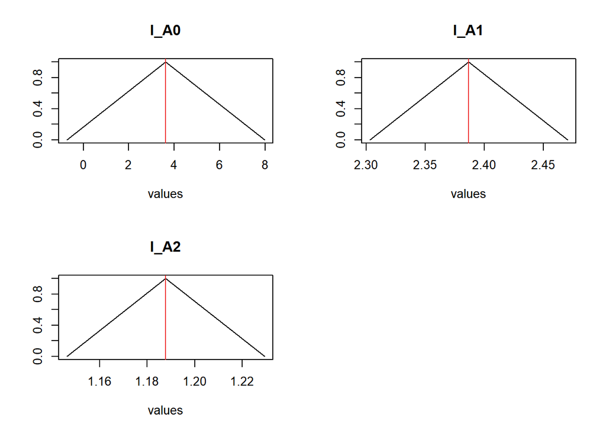

```r
par(mfrow = c(2,2))

for (i in 1:(p + 1)) {
  left.slope <- function(x) {r_slopes[i,1] * (x - r_slopes[i,2]) + 1}
  right.slope <- function(x) {r_slopes[i,3] * (x - r_slopes[i,2]) + 1}

  min_x <- r_f_Ak[i, 1]
  max_x <- r_f_Ak[i, 3]

  x_left <- c(min_x, r_f_Ak[i, 2])
  x_right <- c(r_f_Ak[i, 2], max_x)
  x <- c(x_left, x_right)

  #beta_triangle <- cbind(x, c(left(x_left), right(x_right)))
  #beta_triangle <- as.tibble(beta_triangle)
  #colnames(beta_triangle) <- c("x", "y")
  #
  #q <- ggplot(beta_triangle, aes(x, y)) +
  #  geom_line() +
  #  xlim(min_x, max_x) +
  #  ylim(0, 1) +
  #  geom_vline(xintercept =  coef[i,2], aes(colour = "red")) +
  #  labs(title = str_c("beta", i - 1),
  #     x = "Lambdas",
  #     y = "Coefficients") +
  #  theme(panel.background = element_rect(fill = "white", colour = "grey50"))
  #
  #print(q)

  plot(x, c(left.slope(x_left), right.slope(x_right)), type = "l",
       xlim = c(min_x, max_x), ylim = c(0, 1),
       main = str_c("l_A", i-1), ylab = " ", xlab = "values")
  abline(v = r_slopes[i,2], col = "firebrick2")
}
```

### Fuzzy Predicted Values

Using the fuzzy regression coefficients we have estimated above, we can compute the fuzzy predicted values as well. Note that since we defined the fuzzy regression coefficients as symmetric, the fuzzy predicted values are symmetric as well.

```r
f_1  <- cbind(rep(1, n) * r_f_Ak[1, 1], rep(1, n) * r_f_Ak[1, 2], rep(1, n) * r_f_Ak[1, 3])
f_XL <- X %*% r_f_Ak[2:(p+1), 1]
f_XC <- X %*% r_f_Ak[2:(p+1), 2]
f_XR <- X %*% r_f_Ak[2:(p+1), 3]

f_X <- cbind(f_XL, f_XC, f_XR)
(f_Yhat <- f_1 + f_X)
```

```
##            [,1]     [,2]     [,3]
##  [1,]  8.688198 13.39323 18.09826
##  [2,] 12.824002 17.67942 22.53485
##  [3,] 14.202603 19.10816 24.01371
##  [4,] 17.419339 22.44186 27.46439
##  [5,] 19.257474 24.34684 29.43620
##  [6,] 21.555143 26.72806 31.90097
##  [7,] 22.933744 28.15679 33.37984
##  [8,] 26.150480 31.49050 36.83051
##  [9,] 27.988615 33.39547 38.80233
## [10,] 31.205351 36.72918 42.25301
## [11,] 32.583952 38.15791 43.73187
## [12,] 35.341155 41.01538 46.68960
## [13,] 37.179290 42.92035 48.66141
## [14,] 39.936492 45.77781 51.61914
## [15,] 42.234161 48.15903 54.08391
```

```r
f_Yhat[,3] - f_Yhat[,2]
```

```
##  [1] 4.705032 4.855423 4.905553 5.022525 5.089365 5.172916 5.223046
##  [8] 5.340017 5.406858 5.523829 5.573960 5.674220 5.741061 5.841322
## [15] 5.924873
```

```r
f_Yhat[,2] - f_Yhat[,1]
```

```
##  [1] 4.705032 4.855423 4.905553 5.022525 5.089365 5.172916 5.223046
##  [8] 5.340017 5.406858 5.523829 5.573960 5.674220 5.741061 5.841322
## [15] 5.924873
```

```r
f_Y
```

```
##               y
##  [1,]  7.5 12.5 17.5
##  [2,] 12.0 17.0 22.0
##  [3,] 13.5 18.5 23.5
##  [4,] 17.0 22.0 27.0
##  [5,] 19.0 24.0 29.0
##  [6,] 21.5 26.5 31.5
##  [7,] 23.0 28.0 33.0
##  [8,] 26.5 31.5 36.5
##  [9,] 28.5 33.5 38.5
## [10,] 32.0 37.0 42.0
## [11,] 32.5 38.5 44.5
## [12,] 35.5 41.5 47.5
## [13,] 37.5 43.5 49.5
## [14,] 40.5 46.5 52.5
## [15,] 43.0 49.0 55.0
```

Compute RMSE and MAPE for between the observed fuzzy values $Y$ and the fitted fuzzy values $\hat{Y}$.

```r
### The left slope chosen
# RMSE
(RMSE <- sqrt(sum(rowSums((f_Y - f_Yhat)^2)) / n))
```

```
## [1] 0.9784173
```

```r
# MAPE
f_diff <- f_Y - f_Yhat
for (i in 1:3) {
  f_diff[,i] <- abs(f_diff[,i] / f_Y[,i])
}

(MAPE <- sum(rowSums(f_diff))/n)
```

```
## [1] 0.06272885
```

Compare our method with that of HONG et al.

```r
hong_y <- c(12.4969, 16.9984, 18.4989, 22.0001, 24.0008, 26.5017, 28.0022, 31.5034,
            33.5041, 37.0053, 38.5058, 41.5068, 43.5075, 46.5085, 49.0094)
hong_s <- c(4.6739, 4.8318, 4.8844, 5.0071, 5.0773, 5.1650, 5.2176, 5.3404, 5.4105,
            5.5333, 5.5859, 5.6911, 5.7613, 5.8665, 5.9542)
hong_f_Yhat <- cbind(hong_y - hong_s, hong_y, hong_y + hong_s)
# RMSE
(RMSE <- sqrt(sum(rowSums((f_Y - hong_f_Yhat)^2)) / n))
```

```
## [1] 0.3901702
```

```r
# MAPE
f_diff <- f_Y - hong_f_Yhat
for (i in 1:3) {
  f_diff[,i] <- abs(f_diff[,i] / f_Y[,i])
}

(MAPE <- sum(rowSums(f_diff))/n)
```

```
## [1] 0.01786406
```

The plot of the observed values and the fitted values is shown below.

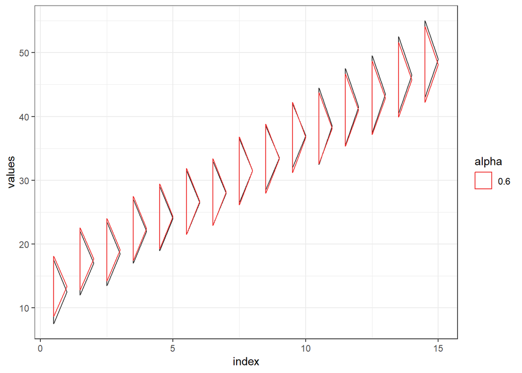